# PC4_SofiaDager

2022-11-24

### PREGUNTA 1: Correlacion

```r
library(rio)
data = import ("data_final_vf.xlsx")
```

Alistamos los datos

```r
summary(data$anemia_2017)
```

```
##    Min. 1st Qu.  Median    Mean 3rd Qu.    Max.    NA's
##    5.90   18.70   26.50   33.42   45.95   80.40       3
```

```r
summary(data$PBI_percapita_2017)
```

```
##     Min.  1st Qu.   Median     Mean  3rd Qu.     Max.     NA's
##    253.8   1971.6   6113.0  15597.5  17218.2 171254.0        4
```

```r
summary(data$gasto_educacion_total_2017)
```

```
##    Min. 1st Qu.  Median    Mean 3rd Qu.    Max.    NA's
##   1.344   3.334   4.362   4.450   5.371  12.416      40
```

vemos NA’s asi que debemos eliminarlos para poder hacer nuestra prueba de correlación.

```r
data1 = data[complete.cases(data$anemia_2017),]
```

```r
data2 = data1[complete.cases(data1$PBI_percapita_2017),]
```

```r
data = data2[complete.cases(data2$gasto_educacion_total_2017),]
```

```r
summary(data$anemia_2017)
```

```
##    Min. 1st Qu.  Median    Mean 3rd Qu.    Max.
##   10.40   17.68   24.60   32.34   44.83   80.40
```

```r
summary(data$PBI_percapita_2017)
```

```
##     Min.  1st Qu.   Median     Mean  3rd Qu.     Max.
##    253.8   1891.0   6336.1  15876.3  17799.1 167517.1
```

```r
summary(data$gasto_educacion_total_2017)
```

```
##    Min. 1st Qu.  Median    Mean 3rd Qu.    Max.
##   1.455   3.349   4.362   4.471   5.374  12.416
```

Ahora que hemos eliminado los NA’s podemos seguir con las correlaciones

**EJERCICIO 1**

```r
library(nortest)
```

```r
lillie.test(data$anemia_2017)
```

```
##
##  Lilliefors (Kolmogorov-Smirnov) normality test
##
## data:  data$anemia_2017
## D = 0.18622, p-value = 2.611e-13
```

```r
lillie.test(data$PBI_percapita_2017)
```

```
##
##  Lilliefors (Kolmogorov-Smirnov) normality test
##
## data:  data$PBI_percapita_2017
## D = 0.25332, p-value < 2.2e-16
```

```r
cor.test(data$anemia_2017,data$PBI_percapita_2017, method = "spearman")
```

```
##
##  Spearman's rank correlation rho
##
## data:  data$anemia_2017 and data$PBI_percapita_2017
## S = 925162, p-value < 2.2e-16
## alternative hypothesis: true rho is not equal to 0
## sample estimates:
##        rho
## -0.8590993
```

El p-value es menor a 0.05. Podemos afirmar que sí hay correlación (negativa) entre el PBI percápita y la anemia en el año 2017 esta es -08590. Es negativa e inversa, pero alta. Esto tiene sentido porque mientras menos dinero tienen las familias, pueden comprar menos productos para alimentar a su familia y por lo tanto, los niños pueden desarrollar anemia (por falta de nutrientes). Por ejemplo, productos como la carne (fuerte fuente de hierro) son caras y familias con menos recursos puede que no tengan oportunidades para adquirirlas. Tambien se puede ver como: si aumenta el PBI, disminuye la anemia.

**EJERCICIO 2**

```r
lillie.test(data$anemia_2017)
```

```
##
##  Lilliefors (Kolmogorov-Smirnov) normality test
##
## data:  data$anemia_2017
## D = 0.18622, p-value = 2.611e-13
```

```r
lillie.test(data$gasto_educacion_total_2017)
```

```
##
##  Lilliefors (Kolmogorov-Smirnov) normality test
##
## data:  data$gasto_educacion_total_2017
## D = 0.081773, p-value = 0.01968
```

```r
cor.test(data$anemia_2017,data$gasto_educacion_total_2017, method = "spearman")
```

```
##
##  Spearman's rank correlation rho
##
## data:  data$anemia_2017 and data$gasto_educacion_total_2017
## S = 599142, p-value = 0.0142
## alternative hypothesis: true rho is not equal to 0
## sample estimates:
##       rho
## -0.203966
```

Al igual que en el ejercicio anterior, en este, el p-value también es menos a 0.05. Podemos afirmar que sí hay correlación (negativa) entre el gasto total y la anemia en el año 2017, es -0,203. Sin embargo, es muy pequeña. Esta correlación se puede explicar desde la perspectiva que mientras mas se gaste por alumno en la educación, podría haber menos anemia. El gobierno podría implementar mejores cafeterias con desayunos y almuerzo en los coelgios. sobre todo para los niños más pequeños, en pleno desarrollo cerebral.

### PREGUNTA 2: REGRESIÓN LINEAL

**EJERCICIO 1**

**modelo 1**

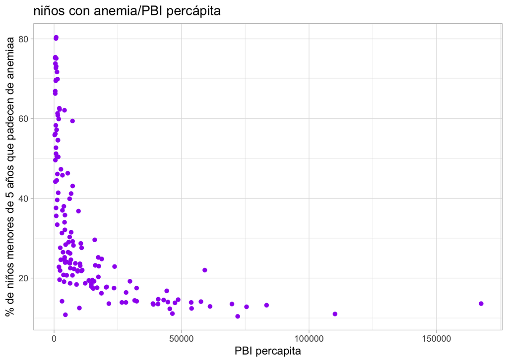

```r
library(ggplot2)
ggplot(data, aes(x=PBI_percapita_2017, y=anemia_2017)) +
geom_point(colour="purple") + xlab("PBI percapita") + ylab("% de niños menores de 5 años que padecen de anemiaa") +
ggtitle("niños con anemia/PBI percápita") +
theme_light()
```

el gráfico nos muestra una dependencia negativa. Esto demuestra que mientras más baje el PBI entonces más niños con anemia habrán.

```r
modelo1 = lm(anemia_2017~PBI_percapita_2017, data=data)
anova(modelo1)
```

```
## Analysis of Variance Table
##
## Response: anemia_2017
##                     Df Sum Sq Mean Sq F value    Pr(>F)
## PBI_percapita_2017   1  14485   14485  53.251 1.905e-11 ***
## Residuals          142  38627     272
## ---
## Signif. codes:  0 '***' 0.001 '**' 0.01 '*' 0.05 '.' 0.1 ' ' 1
```

```r
summary(modelo1)
```

```
##
## Call:
## lm(formula = anemia_2017 ~ PBI_percapita_2017, data = data)
##
## Residuals:
##     Min      1Q  Median      3Q     Max
## -26.430 -12.691  -6.228   9.354  46.133
##
## Coefficients:
##                      Estimate Std. Error t value Pr(>|t|)
## (Intercept)         3.914e+01  1.660e+00  23.576  < 2e-16 ***
## PBI_percapita_2017 -4.278e-04  5.863e-05  -7.297  1.9e-11 ***
## ---
## Signif. codes:  0 '***' 0.001 '**' 0.01 '*' 0.05 '.' 0.1 ' ' 1
##
## Residual standard error: 16.49 on 142 degrees of freedom
## Multiple R-squared:  0.2727, Adjusted R-squared:  0.2676
## F-statistic: 53.25 on 1 and 142 DF,  p-value: 1.905e-11
```

**interpretación:** vemos que el p valor es menor a 0.05, por lo que sí ayuda a explicar el modelo y es una variable que aporta al modelo vemos que el nivel explicativo es 27% aproximadamente. por ultimo, la ecuacion es : **Y = 3.914e+01 - 4.278e-04 * X** por todo lo que hemos visto a través de las pruebas, podríamos entonces decir que el hecho de que haya más PBI hará que haya menos niños con anemia.

**modelo 2**

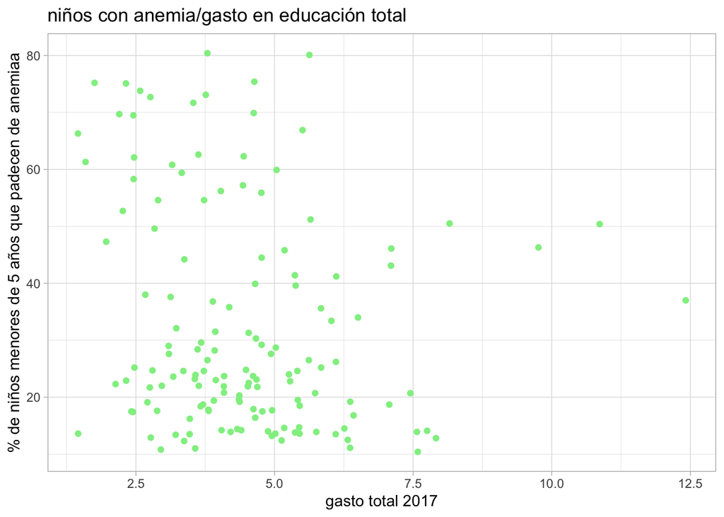

```r
ggplot(data, aes(x=gasto_educacion_total_2017, y=anemia_2017)) +
geom_point(colour="lightgreen") + xlab("gasto total 2017") + ylab("% de niños menores de 5 años que padecen de anemiaa") +
ggtitle("niños con anemia/gasto en educación total") +
theme_light()
```

vemos que los datos en este gráfico son demasiado dispersos, por lo que podríamos decir que no es claro que haya una correlación. Al menos visualmente, pero en las pruebas hemos visto que si hay. es probable que el grafico se vea asi porque la correlación entre las variables es pequeña.

```r
modelo2 = lm(anemia_2017~gasto_educacion_total_2017, data=data)
anova(modelo1)
```

```
## Analysis of Variance Table
##
## Response: anemia_2017
##                     Df Sum Sq Mean Sq F value    Pr(>F)
## PBI_percapita_2017   1  14485   14485  53.251 1.905e-11 ***
## Residuals          142  38627     272
## ---
## Signif. codes:  0 '***' 0.001 '**' 0.01 '*' 0.05 '.' 0.1 ' ' 1
```

```r
summary(modelo2)
```

```
##
## Call:
## lm(formula = anemia_2017 ~ gasto_educacion_total_2017, data = data)
##
## Residuals:
##     Min      1Q  Median      3Q     Max
## -24.533 -14.287  -8.177  14.293  49.981
##
## Coefficients:
##                            Estimate Std. Error t value Pr(>|t|)
## (Intercept)                 40.9346     4.4080   9.286  2.5e-16 ***
## gasto_educacion_total_2017  -1.9217     0.9198  -2.089   0.0385 *
## ---
## Signif. codes:  0 '***' 0.001 '**' 0.01 '*' 0.05 '.' 0.1 ' ' 1
##
## Residual standard error: 19.05 on 142 degrees of freedom
## Multiple R-squared:  0.02982,    Adjusted R-squared:  0.02299
## F-statistic: 4.365 on 1 and 142 DF,  p-value: 0.03847
```

vemos que el nivel de explicación modelo es 2% aproximadamente. tiene sentido, pues cuando hicimos la prueba de correlación nos dimos cuenta de que era baja por ultimo, la ecuacion es : **Y = 40.9346 - 1.9217 * X**

**modelo 3**

```r
modelo3 = lm(anemia_2017 ~ PBI_percapita_2017 + gasto_educacion_total_2017, data)
anova(modelo3)
```

```
## Analysis of Variance Table
##
## Response: anemia_2017
##                             Df Sum Sq Mean Sq F value    Pr(>F)
## PBI_percapita_2017           1  14485 14485.2 54.3926 1.281e-11 ***
## gasto_educacion_total_2017   1   1077  1077.1  4.0446   0.04622 *
## Residuals                  141  37550   266.3
## ---
## Signif. codes:  0 '***' 0.001 '**' 0.01 '*' 0.05 '.' 0.1 ' ' 1
```

```r
summary(modelo3)
```

```
##
## Call:
## lm(formula = anemia_2017 ~ PBI_percapita_2017 + gasto_educacion_total_2017,
##     data = data)
##
## Residuals:
##     Min      1Q  Median      3Q     Max
## -28.766 -12.056  -5.566  11.094  43.220
##
## Coefficients:
##                              Estimate Std. Error t value Pr(>|t|)
## (Intercept)                 4.612e+01  3.844e+00  12.000  < 2e-16 ***
## PBI_percapita_2017         -4.210e-04  5.811e-05  -7.245 2.59e-11 ***
## gasto_educacion_total_2017 -1.587e+00  7.893e-01  -2.011   0.0462 *
## ---
## Signif. codes:  0 '***' 0.001 '**' 0.01 '*' 0.05 '.' 0.1 ' ' 1
##
## Residual standard error: 16.32 on 141 degrees of freedom
## Multiple R-squared:  0.293,  Adjusted R-squared:  0.283
## F-statistic: 29.22 on 2 and 141 DF,  p-value: 2.419e-11
```

**interpretación:** vemos que ambos p valores son menores a 0.05, por lo que sí ayuda a explicar el modelo y es una variable que aporta al modelo. los *** puestos por el programa indican que es bastante significativo para el mdoelo

**EJERCICIO 2**

Para hacer la RLM, primero sacaremos la correlacion entre las varibales independientes nuevas y nuestra variable dependiente. Primero, eliminemos los NA’s

```r
summary(data$ingresos_nosubvenciones_2017)
```

```
##    Min. 1st Qu.  Median    Mean 3rd Qu.    Max.    NA's
##   7.198  17.443  25.097  26.744  33.787  99.569      31
```

```r
summary(data$fin_educ_prim_2017)
```

```
##    Min. 1st Qu.  Median    Mean 3rd Qu.    Max.    NA's
##   37.92   87.20   97.29   92.25  101.51  121.72      44
```

```r
summary(data$inscripcion_preprimario_2017)
```

```
##     Min.  1st Qu.   Median     Mean  3rd Qu.     Max.     NA's
##   0.7419  40.9621  78.9620  69.6878  94.2945 164.5540       32
```

```r
data = data[complete.cases(data$ingresos_nosubvenciones_2017),]
data = data[complete.cases(data$fin_educ_prim_2017),]
data = data[complete.cases(data$inscripcion_preprimario_2017),]
summary(data$ingresos_nosubvenciones_2017)
```

```
##    Min. 1st Qu.  Median    Mean 3rd Qu.    Max.
##   7.198  17.644  27.104  26.752  35.036  59.180
```

```r
summary(data$fin_educ_prim_2017)
```

```
##    Min. 1st Qu.  Median    Mean 3rd Qu.    Max.
##   49.61   90.86   97.45   93.13  101.38  121.72
```

```r
summary(data$inscripcion_preprimario_2017)
```

```
##    Min. 1st Qu.  Median    Mean 3rd Qu.    Max.
##   2.926  46.901  80.548  71.314  94.650 116.794
```

Ahora, la prueba de correlación

```r
cor.test(data$anemia_2017,data$ingresos_nosubvenciones_2017, method = "spearman")
```

```
##
##  Spearman's rank correlation rho
##
## data:  data$anemia_2017 and data$ingresos_nosubvenciones_2017
## S = 105203, p-value = 5.89e-06
## alternative hypothesis: true rho is not equal to 0
## sample estimates:
##        rho
## -0.4964934
```

Vemos una correlación negativa y mediana (49.6%). Tiene sentido, pues a mientras más ingresos para la familia, habrá menos anemia. El p-value es menor a 0.05,por lo que sí es relevante

```r
cor.test(data$anemia_2017,data$fin_educ_prim_2017, method = "spearman")
```

```
##
##  Spearman's rank correlation rho
##
## data:  data$anemia_2017 and data$fin_educ_prim_2017
## S = 98863, p-value = 0.0002981
## alternative hypothesis: true rho is not equal to 0
## sample estimates:
##       rho
## -0.406302
```

Vemos una correlación negativa y mediana (40.6%). Tiene sentido, pues a más personas que termianan la primaria, más oportunidad de trabajo y por lo tanto un mejor sueldo, lo que ayudará a que menos niños tengan anemia, ya que, podrán estar mejor alimentados. El p-value es menor a 0.05,por lo que sí es relevante

```r
cor.test(data$anemia_2017,data$inscripcion_preprimario_2017, method = "spearman")
```

```
##
##  Spearman's rank correlation rho
##
## data:  data$anemia_2017 and data$inscripcion_preprimario_2017
## S = 111087, p-value = 4.886e-08
## alternative hypothesis: true rho is not equal to 0
## sample estimates:
##        rho
## -0.5801835
```

Vemos una correlación negativa y mediana (58%). Tiene sentido, porque mientras más niños en el colegio, hay mejor control de ellos y puede que los colegios apoyen con comidas, lo que haría que el % de anemia disminuya. El p-value es menor a 0.05,por lo que sí es relevante

```r
modelo4 = lm(anemia_2017 ~ PBI_percapita_2017 + gasto_educacion_total_2017 + ingresos_nosubvenciones_2017 + fin_educ_prim_2017 + inscripcion_preprimario_2017, data)
anova(modelo3)
```

```
## Analysis of Variance Table
##
## Response: anemia_2017
##                             Df Sum Sq Mean Sq F value    Pr(>F)
## PBI_percapita_2017           1  14485 14485.2 54.3926 1.281e-11 ***
## gasto_educacion_total_2017   1   1077  1077.1  4.0446   0.04622 *
## Residuals                  141  37550   266.3
## ---
## Signif. codes:  0 '***' 0.001 '**' 0.01 '*' 0.05 '.' 0.1 ' ' 1
```

```r
summary(modelo4)
```

```
##
## Call:
## lm(formula = anemia_2017 ~ PBI_percapita_2017 + gasto_educacion_total_2017 +
##     ingresos_nosubvenciones_2017 + fin_educ_prim_2017 + inscripcion_preprimario_2017,
##     data = data)
##
## Residuals:
##     Min      1Q  Median      3Q     Max
## -31.323  -6.078  -0.630   4.059  36.662
##
## Coefficients:
##                                Estimate Std. Error t value Pr(>|t|)
## (Intercept)                   8.869e+01  9.575e+00   9.262 9.96e-14 ***
## PBI_percapita_2017           -2.170e-04  7.303e-05  -2.971  0.00408 **
## gasto_educacion_total_2017    9.501e-01  8.203e-01   1.158  0.25077
## ingresos_nosubvenciones_2017 -2.147e-01  1.509e-01  -1.423  0.15936
## fin_educ_prim_2017           -4.899e-01  1.332e-01  -3.679  0.00046 ***
## inscripcion_preprimario_2017 -1.389e-01  6.534e-02  -2.126  0.03709 *
## ---
## Signif. codes:  0 '***' 0.001 '**' 0.01 '*' 0.05 '.' 0.1 ' ' 1
##
## Residual standard error: 11.14 on 69 degrees of freedom
## Multiple R-squared:  0.6128, Adjusted R-squared:  0.5847
## F-statistic: 21.84 on 5 and 69 DF,  p-value: 4.817e-13
```

**interpretación:** vemos que todos p valores son menores a 0.05, menos gastos educativos totales e ingresos, no subvenciones. Podemos decir que todas las variables a excepción de esas dos ayudan a explicar el modelo; los *** puestos por el programa indican que es bastante significativo para el mdoelo Respecto a las otras dos variables, estas no son significativas para el modelo.

vemos que el nivel de explicación modelo es de 58% aproximadamente. Esta es una explicación mediana, la cual es confiable, pero se debe de tener en cuenta que tiene dos variables que no son significativas para el modelo.